# Chinese PhDs in the United States, Europe, and United Kingdom (1905-1962)

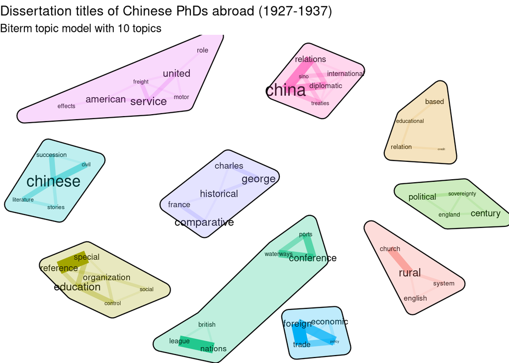

```r
plot(model10p2, top_n = 8,
     title = "Dissertation titles of Chinese PhDs abroad (1927-1937)",
     subtitle = "Biterm topic model with 10 topics")
```

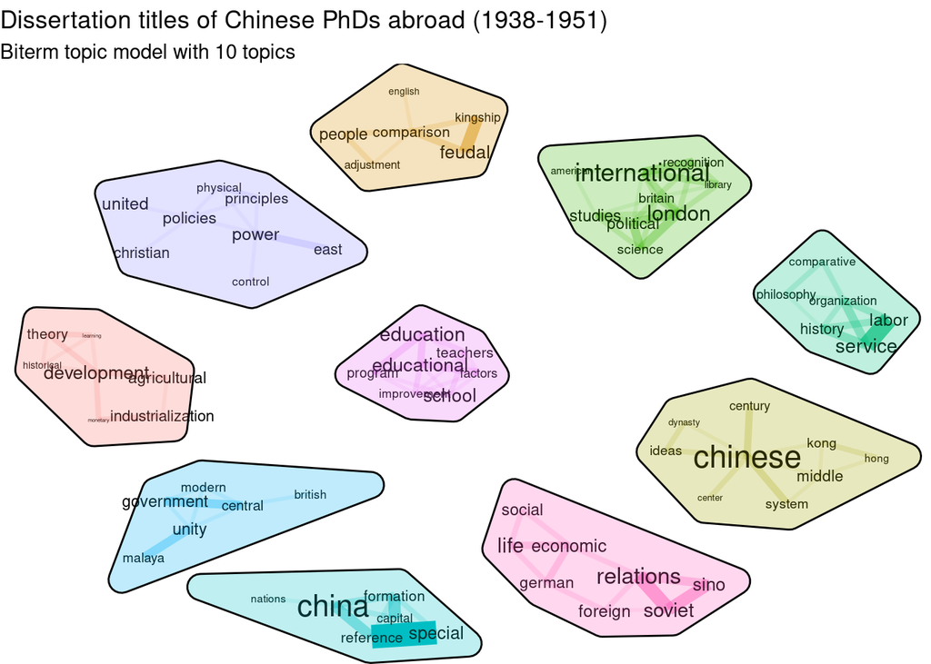

```r
plot(model10p3, top_n = 10,
     title = "Dissertation titles of Chinese PhDs abroad (1938-1951)",
     subtitle = "Biterm topic model with 10 topics")
```

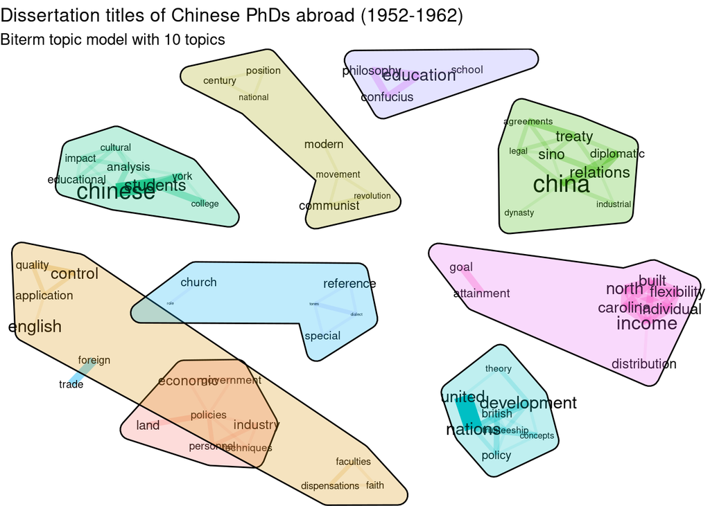

```r
plot(model10p4, top_n = 10,
     title = "Dissertation titles of Chinese PhDs abroad (1952-1962)",
     subtitle = "Biterm topic model with 10 topics")
```

## Named Entity Recognition

Extract named entities (persons, locations/GPE, organizations, events) from titles to identify China-focused theses:

```r
library(histtext)

phd_all_master_ner <- phd_all_master %>% drop_na(Thesis)
phd_all_master_ner <- ner_on_df(phd_all_master_ner, text_column = "Thesis", id_column = "RID")

phd_all_master_ner %>% group_by(Type) %>% count(sort = TRUE)
```

A total of 2885 named entities were found, distributed as follows:

```r
phd_all_master_ner %>% group_by(Type) %>% count(sort = TRUE)
```

| Type | n |
| --- | --- |
| GPE | 930 |
| NORP | 592 |
| DATE | 317 |
| PERSON | 301 |
| CARDINAL | 208 |
| ORG | 169 |
| LOC | 135 |
| LANGUAGE | 62 |
| WORK_OF_ART | 42 |
| EVENT | 34 |

[output cut: 7 more lines]

The named entities were curated and manually coded using a combination of R (tidyverse) and Excel to classify the entities and identify those related to China and Chinese issues. The resulting dataset was used for statistical analyses of individual entity types and served as a basis for analyzing China-centered theses.

### Locations/GPE

```r
# upload clean list of locations/GPE

library(readr)
phd_loc_clean_meta <- read_delim("Data/phd_loc_clean_meta.csv",
    delim = ";", escape_double = FALSE, trim_ws = TRUE)
```

```r
phd_loc_clean_meta %>% group_by(Place) %>% count(sort = TRUE)
```

| Place | n |
| --- | --- |
| China | 488 |
| United States | 59 |
| France | 27 |
| England | 16 |
| Germany | 12 |
| Japan | 11 |
| Manchuria | 9 |
| New York | 9 |
| Chicago | 8 |
| Far East | 8 |

[output cut: 236 more lines]

### Events

```r
# upload clean list of events

library(readr)
phd_event_clean_meta <- read_delim("Data/phd_event_clean_meta.csv",
    delim = ";", escape_double = FALSE, trim_ws = TRUE)
```

```r
phd_event_clean_meta %>% group_by(EventType) %>% count(sort = TRUE)
```

| EventType | n |
| --- | --- |
| International War | 12 |
| Treaty/Conference | 8 |
| Revolution | 7 |
| Civil War | 6 |

```r
phd_event_clean_meta %>% group_by(Event2) %>% count(sort = TRUE)
```

| Event2 | n |
| --- | --- |
| 1911 Revolution | 7 |
| World War 2 | 7 |
| Taiping | 4 |
| Washington Disarmament Conference (1922) | 3 |
| World War 1 | 3 |
| Opium War/Unequal Treaties | 2 |
| Paris Peace Conference (1919) | 2 |
| Geneva Conference | 1 |
| Hague Conference (1899, 1907) | 1 |
| Nien Rebellion (1851-1868) | 1 |

[output cut: 2 more lines]

### Organizations

```r
# upload clean list of organizations

library(readr)
phd_org_clean_meta <- read_delim("Data/phd_org_clean_meta.csv",
    delim = ";", escape_double = FALSE, trim_ws = TRUE)
```

```r
phd_org_clean_meta %>% group_by(Text_clean2) %>% count(sort = TRUE)
```

| Text_clean2 | n |
| --- | --- |
| United Nations | 15 |
| League Of Nations | 14 |
| United States Congress | 3 |
| British Parliament | 2 |
| Columbia University | 2 |
| House Of Representatives | 2 |
| Kuomintang | 2 |
| United States Department Of Agriculture | 2 |
| American Cyanamid Company | 1 |
| American Railway Association | 1 |

[output cut: 64 more lines]

```r
phd_org_clean_meta %>% group_by(type2) %>% count(sort = TRUE)
```

| type2 | n |
| --- | --- |
| International Organization | 31 |
| Academic Institution | 20 |
| Legislative | 11 |
| Administration | 9 |
| Financial Institution | 8 |
| Central Government | 6 |
| Church | 4 |
| Health Institution | 4 |
| Judiciary | 4 |
| Company | 3 |

[output cut: 3 more lines]

```r
phd_org_clean_meta %>% group_by(country) %>% count(sort = TRUE)
```

| country | n |
| --- | --- |
| Global | 32 |
| China | 29 |
| US | 29 |
| Germany | 7 |
| France | 5 |
| UK | 4 |
| Italy | 2 |

### Persons

```r
# upload clean list of persons

library(readr)
phd_pers_clean_meta <- read_delim("Data/phd_pers_clean_meta.csv",
    delim = ";", escape_double = FALSE, trim_ws = TRUE)
```

```r
phd_pers_clean_meta %>% group_by(Text_clean2) %>% count(sort = TRUE)
```

| Text_clean2 | n |
| --- | --- |
| Sun Yat-Sen | 11 |
| John Dewey | 7 |
| Laozi | 6 |
| Chuang Tzu | 3 |
| Lu Xun | 3 |
| Mozi | 3 |
| Wang Yangming | 3 |
| Albert Schweitzer | 2 |
| Aristotle | 2 |
| Bernard Bosanquet | 2 |

[output cut: 153 more lines]

## China-Centered Theses

```r
# upload compiled list of china-centered theses

library(readr)
china_theses_all <- read_delim("Data/china_theses_all.csv",
    delim = ";", escape_double = FALSE, trim_ws = TRUE)
```

```r
names(china_theses_all)
```

```
##  [1] "RID"         "Region"      "Country"     "Discipline"  "Degree_Year"
##  [6] "Thesis"      "Title_Src"   "totalDisc"   "Field"       "totalField"
```

The dataset of China-centered theses includes the following information: a unique dissertation identifier (RID); region and country of graduation (Region, Country); discipline and field of study (Discipline, Field); year of graduation (Degree_Year); dissertation title in both its original language and translated form (Title_Src, Thesis); and the total number of dissertations within each discipline and field (totalDisc, totalField), which is used for statistical computations.

### Disciplines

```r
china_theses_all %>% group_by(Field) %>% count(sort = TRUE)
```

| Field | n |
| --- | --- |
| Humanities and social sciences | 849 |
| Biological sciences | 53 |
| Physical and earth sciences | 38 |
| Engineering sciences | 14 |
| Health sciences | 14 |
| Other | 6 |

```r
china_theses_all %>% group_by(Discipline) %>% count(sort = TRUE)
```

| Discipline | n |
| --- | --- |
| Economics | 203 |
| Education | 105 |
| International Law and Relations | 98 |
| History | 80 |
| Law | 80 |
| Political Science | 67 |
| Sociology | 63 |
| Philosophy and Theology | 56 |
| Linguistics and Literature | 42 |
| Anthropology and Archaeology | 20 |

[output cut: 22 more lines]

```r
# Proportion

china_theses_fields <- china_theses_all %>% group_by(Field, totalField) %>% count()
china_theses_fields <- china_theses_fields %>% mutate(percent = round(n/totalField*100, 2))
china_theses_fields %>% arrange(desc(n))
```

| Field | totalField | n | percent |
| --- | --- | --- | --- |
| Humanities and social sciences | 1622 | 849 | 52.34 |
| Biological sciences | 727 | 53 | 7.29 |
| Physical and earth sciences | 1133 | 38 | 3.35 |
| Engineering sciences | 714 | 14 | 1.96 |
| Health sciences | 490 | 14 | 2.86 |
| Other | 17 | 6 | 35.29 |

```r
china_theses_disciplines <- china_theses_all %>% group_by(Discipline, totalDisc) %>% count()
china_theses_disciplines <- china_theses_disciplines %>% mutate(percent = round(n/totalDisc*100, 2))
china_theses_disciplines %>% arrange(desc(n))
```

| Discipline | totalDisc | n | percent |
| --- | --- | --- | --- |
| Economics | 409 | 203 | 49.63 |
| Education | 180 | 105 | 58.33 |
| International Law and Relations | 188 | 98 | 52.13 |
| History | 103 | 80 | 77.67 |
| Law | 163 | 80 | 49.08 |
| Political Science | 139 | 67 | 48.20 |
| Sociology | 88 | 63 | 71.59 |
| Philosophy and Theology | 150 | 56 | 37.33 |
| Linguistics and Literature | 81 | 42 | 51.85 |
| Anthropology and Archaeology | 27 | 20 | 74.07 |

[output cut: 22 more lines]

```r
china_theses_disciplines %>% arrange(desc(percent))
```

| Discipline | totalDisc | n | percent |
| --- | --- | --- | --- |
| Physical Education | 1 | 1 | 100.00 |
| Fine Arts | 18 | 16 | 88.89 |
| Library Science | 5 | 4 | 80.00 |
| History | 103 | 80 | 77.67 |
| Anthropology and Archaeology | 27 | 20 | 74.07 |
| Sociology | 88 | 63 | 71.59 |
| Journalism | 6 | 4 | 66.67 |
| Geography | 31 | 19 | 61.29 |
| Education | 180 | 105 | 58.33 |
| International Law and Relations | 188 | 98 | 52.13 |

[output cut: 22 more lines]